# Clustering

### Sunah Park

This markdown file is created by Sunah Park for extended lab exercises in the book *An Introduction to Statistical Learning with Applications in R* [(ISLR)](https://www-bcf.usc.edu/~gareth/ISL/ISLR%20First%20Printing.pdf).

### Setup for code chunks

```r
rm(list=ls())
# default r markdown global options in document
knitr::opts_chunk$set(
   ########## Text results ##########
    echo=TRUE,
    warning=FALSE, # to preserve warnings in the output
    error=FALSE, # to preserve errors in the output
    message=FALSE, # to preserve messages
    strip.white=TRUE, # to remove the white lines in the beginning or end of a source chunk in the output

    ########## Cache ##########
    cache=TRUE,

    ########## Plots ##########
    fig.path="", # prefix to be used for figure filenames
    fig.width=8,
    fig.height=6,
    dpi=200
)
```

```r
library(ISLR)
library(ggplot2)
library(caret)
```

## **1. K-Means Clustering**

```r
set.seed(2)
x<-matrix(rnorm(50*2), ncol=2)
x[1:25,1]<-x[1:25,1]+3
x[1:25,2]<-x[1:25,2]-4
```

We now perform K-means clustering with K=2.

```r
km.out<-kmeans(x, centers=2, nstart=20, iter.max=1000) # centers: number of clusters, iter.max: maximum number of iteration, nstart: number of random sets
names(km.out)
```

```
## [1] "cluster"      "centers"      "totss"        "withinss"
## [5] "tot.withinss" "betweenss"    "size"         "iter"
## [9] "ifault"
```

```r
km.out$cluster
```

```
##  [1] 2 2 2 2 2 2 2 2 2 2 2 2 2 2 2 2 2 2 2 2 2 2 2 2 2 1 1 1 1 1 1 1 1 1 1
## [36] 1 1 1 1 1 1 1 1 1 1 1 1 1 1 1
```

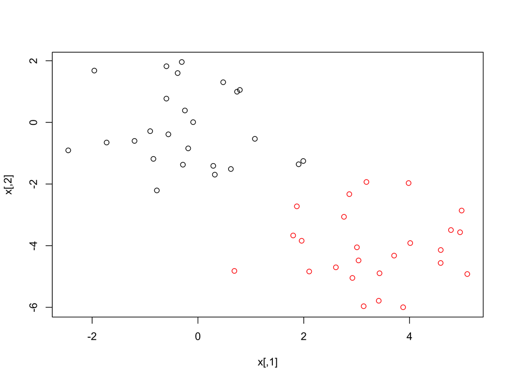

```r
plot(x, col=(km.out$cluster))
```

The cluster assignments of the 50 observations are contained in km.out$cluster. The K-means clustering perfectly separated the observations into two clusters even though we did not supply any group information to kmeans(2).  
Here the observations can be easily plotted because they are two-dimensional. If there were more than two variables then we could instead perform PCA and plot the first two principal components score vectors.

For real data, however, in general we do not know the true number of clusters. We could instead have performed K-Means clustering with K=3.

```r
set.seed(4)
km.out<-kmeans(x, centers=3, nstart=20)
names(km.out)
```

```
## [1] "cluster"      "centers"      "totss"        "withinss"
## [5] "tot.withinss" "betweenss"    "size"         "iter"
## [9] "ifault"
```

```r
km.out
```

```
## K-means clustering with 3 clusters of sizes 10, 23, 17
##
## Cluster means:
##         [,1]        [,2]
## 1  2.3001545 -2.69622023
## 2 -0.3820397 -0.08740753
## 3  3.7789567 -4.56200798
##
## Clustering vector:
##  [1] 3 1 3 1 3 3 3 1 3 1 3 1 3 1 3 1 3 3 3 3 3 1 3 3 3 2 2 2 2 2 2 2 2 2 2
## [36] 2 2 2 2 2 2 2 2 1 2 1 2 2 2 2
##
## Within cluster sum of squares by cluster:
## [1] 19.56137 52.67700 25.74089
##  (between_SS / total_SS =  79.3 %)
##
## Available components:
##
## [1] "cluster"      "centers"      "totss"        "withinss"
## [5] "tot.withinss" "betweenss"    "size"         "iter"
## [9] "ifault"
```

```r
km.out$cluster
```

```
##  [1] 3 1 3 1 3 3 3 1 3 1 3 1 3 1 3 1 3 3 3 3 3 1 3 3 3 2 2 2 2 2 2 2 2 2 2
## [36] 2 2 2 2 2 2 2 2 1 2 1 2 2 2 2
```

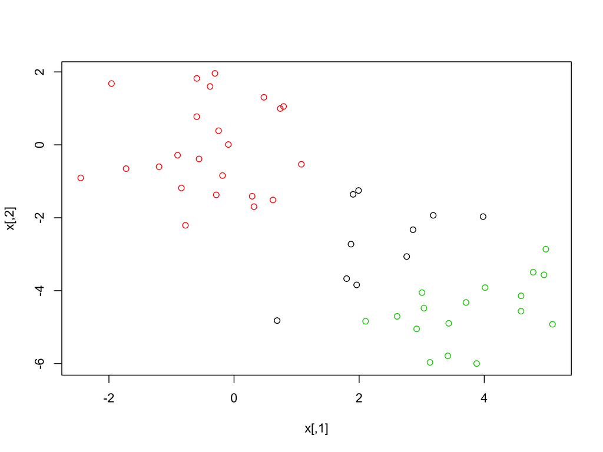

```r
plot(x, col=(km.out$cluster))
```

To run the kmeans() function in R with multiple initial cluster assignments, we use the nstart argument. If a value of nstart greater than one is used, the K-means clustering will be performed using multiple random assignments and the kmeans() function will report only the best results.

```r
set.seed(3)
km.out1<-kmeans(x, centers=3, nstart=1)
km.out1$withinss # Vector of within-cluster sum of squares
```

```
## [1] 18.88549 65.40068 20.04575
```

```r
km.out1$tot.withinss # total within-cluster sum of squares=sum(withinss)
```

```
## [1] 104.3319
```

```r
km.out20<-kmeans(x, centers=3, nstart=20)
km.out20$withinss # Vector of within-cluster sum of squares
```

```
## [1] 25.74089 19.56137 52.67700
```

```r
km.out20$tot.withinss
```

```
## [1] 97.97927
```

It is strongly recommended running K-means clustering with a large value of nstart, such as 20 or 50, since otherwise an undesirable local optimum may be obtained.

## **2. Hierarchical Clustering**

The hclust() function implements hierarchical clustering.

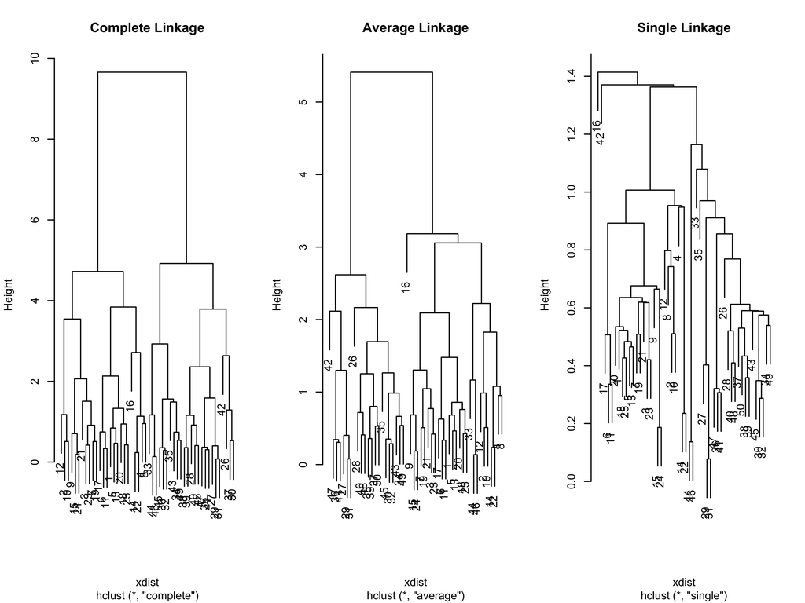

```r
xdist<-dist(x) # 50 times 50 inter-observation Euclidean distance matrix
hc.complete<-hclust(xdist, method="complete") # hclust with complete linkage
hc.average<-hclust(xdist, method="average") # hclust with average linkage
hc.single<-hclust(xdist, method="single") # hclust with single linkage

par(mfrow=c(1,3))
plot(hc.complete, main="Complete Linkage")
plot(hc.average, main="Average Linkage")
plot(hc.single, main="Single Linkage")
```

To determine the cluster labels for each observation associated with a given cut of the dendrogram, we can use the cutree() function.

```r
cutree(hc.complete, 2)
```

```
##  [1] 1 1 1 1 1 1 1 1 1 1 1 1 1 1 1 1 1 1 1 1 1 1 1 1 1 2 2 2 2 2 2 2 2 2 2
## [36] 2 2 2 2 2 2 2 2 2 2 2 2 2 2 2
```

```r
cutree(hc.average,2)
```

```
##  [1] 1 1 1 1 1 1 1 1 1 1 1 1 1 1 1 1 1 1 1 1 1 1 1 1 1 2 2 2 2 2 2 2 1 2 2
## [36] 2 2 2 2 2 2 2 2 1 2 1 2 2 2 2
```

```r
cutree(hc.single,2)
```

```
##  [1] 1 1 1 1 1 1 1 1 1 1 1 1 1 1 1 2 1 1 1 1 1 1 1 1 1 1 1 1 1 1 1 1 1 1 1
## [36] 1 1 1 1 1 1 1 1 1 1 1 1 1 1 1
```

```r
cutree(hc.single,4)
```

```
##  [1] 1 1 1 1 1 1 1 1 1 1 1 1 1 1 1 2 1 1 1 1 1 1 1 1 1 3 3 3 3 3 3 3 3 3 3
## [36] 3 3 3 3 3 3 4 3 3 3 3 3 3 3 3
```

For this data, complete and average linkage generally separate the observations into their correct groups. However, single linkage identifies one point as belonging to its own cluster. A more sensible answer is obtained when four clusters are selected, although there are still two singletons.

To scale the variables before performing hierarchical clustering of the observations, we use the scale() function.

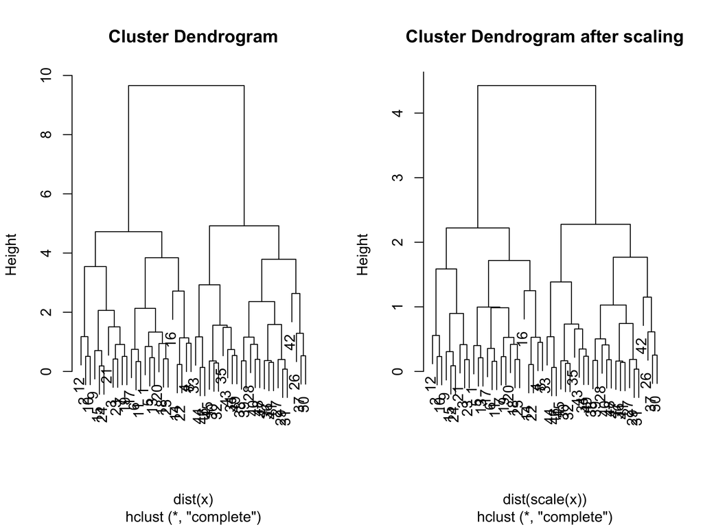

```r
par(mfrow=c(1,2))
plot(hclust(dist(x), method="complete"), main="Cluster Dendrogram")
plot(hclust(dist(scale(x)), method="complete"), main="Cluster Dendrogram after scaling")
```

Correlation-based distance can be computed using the as.dist() function, which converts an arbitrary square symmetric matrix into a form that the hclust() function recognizes as a distance matrix. However, this only makes sense for data with at least three features since the absolute correlation between any two observations with measurements on two features is always 1.

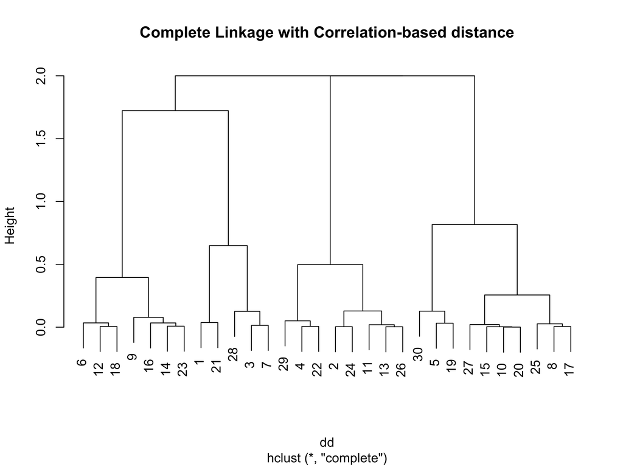

```r
x<-matrix(rnorm(30*3), ncol=3)
dd<-as.dist(1-cor(t(x)))
plot(hclust(dd, method="complete"), main="Complete Linkage with Correlation-based distance")
```